# Exercise 1 Solutions

This exercise will involve estimating causal effect parameters using a difference-in-differences identification strategy that involves conditioning on covariates in the parallel trends assumption and possibly allows for anticipation effects.

In particular, we will use data from the National Longitudinal Study of Youth to learn about causal effects of job displacement (where job displacement roughly means “losing your job through no fault of your own” — a mass layoff is a main example).

To start with, load the data from the file `job_displacement_data.RData` by running

```r
load("job_displacement_data.RData")
```

which will load a `data.frame` called `job_displacement_data`. This is what the data looks like

```r
head(job_displacement_data)
```

```
##        id year group income female white occ_score
## 1 7900002 1984     0  31130      1     1         4
## 2 7900002 1985     0  32200      1     1         3
## 3 7900002 1986     0  35520      1     1         4
## 4 7900002 1987     0  43600      1     1         4
## 5 7900002 1988     0  39900      1     1         4
## 6 7900002 1990     0  38200      1     1         4
```

You can see that the data contains the following columns:

- `id` - an individual identifier
- `year` - the year for this observation
- `group` - the year that person lost his/her job. `group=0` for those that do not lose a job in any period being considered.
- `income` - a person’s wage and salary income in this year
- `female` - 1 for females, 0 for males
- `white` - 1 for white, 0 for non-white

For the results below, we will mainly use the `did` package which you can install using `install.packages("did")`, and you can load it using

```r
library(did)
```

## Question 1

We will start by computing group-time average treatment effects without including any covariates in the parallel trends assumption.

1. Use the `did` package to compute all available group-time average treatment effects.

   ```r
   no_covs <- att_gt(yname="income",
                     tname="year",
                     idname="id",
                     gname="group",
                     data=job_displacement_data)
   summary(no_covs)
   ```

   ```
   ##
   ## Call:
   ## att_gt(yname = "income", tname = "year", idname = "id", gname = "group",
   ##     data = job_displacement_data)
   ##
   ## Reference: Callaway, Brantly and Pedro H.C. Sant'Anna.  "Difference-in-Differences with Multiple Time Periods." Journal of Econometrics, Vol. 225, No. 2, pp. 200-230, 2021. <https://doi.org/10.1016/j.jeconom.2020.12.001>, <https://arxiv.org/abs/1803.09015>
   ##
   ## Group-Time Average Treatment Effects:
   ##  Group Time    ATT(g,t) Std. Error [95% Simult.  Conf. Band]
   ##   1985 1985  -9455.7583   4118.037   -19880.5314    969.0147
   ##   1985 1986 -14981.1547   4641.561   -26731.2230  -3231.0863 *
   ##   1985 1987  -6129.2132   4672.056   -17956.4805   5698.0542
   ##   1985 1988  -4815.9179   5005.777   -17487.9974   7856.1616
   ##   1985 1990  -8011.9173   6064.705   -23364.6623   7340.8277
   ##   1985 1991  -8164.4924   6243.380   -23969.5517   7640.5669
   ```

   [output cut: 64 more lines]

2. *Bonus Question* Try to manually calculate $ATT(g=1992, t=1992)$. Can you calculate exactly the same number as in part (a)?

   ```r
   mean(subset(job_displacement_data, group==1992 & year==1992)$income) -
     mean(subset(job_displacement_data, group==1992 & year==1991)$income) -
     ( mean(subset(job_displacement_data, group==0 & year==1992)$income) -
     mean(subset(job_displacement_data, group==0 & year==1991)$income) )
   ```

   ```
   ## [1] -8990.85
   ```

3. Aggregate the group-time average treatment effects into an event study and plot the results. What do you notice? Is there evidence against parallel trends?

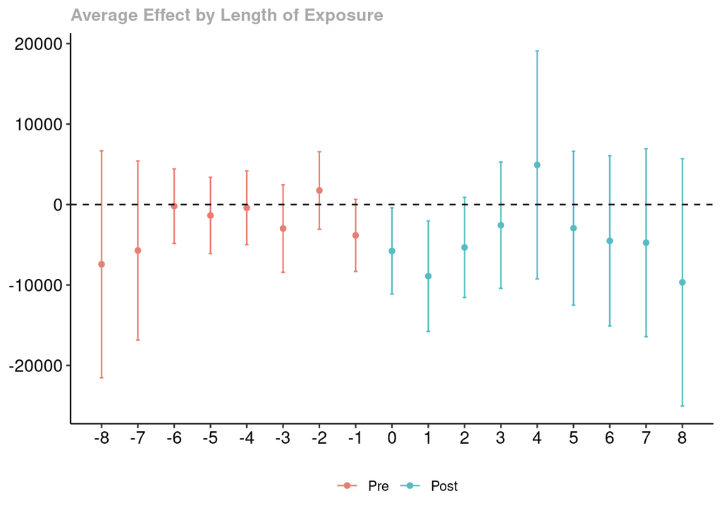

   ```r
   no_covs_es <- aggte(no_covs, type="dynamic")
   ggdid(no_covs_es)
   ```

4. Aggregate the group-time average treatment effects into a single overall treatment effect. How do you interpret the results?

   ```r
   no_covs_overall <- aggte(no_covs, type="group")
   summary(no_covs_overall)
   ```

   ```
   ##
   ## Call:
   ## aggte(MP = no_covs, type = "group")
   ##
   ## Reference: Callaway, Brantly and Pedro H.C. Sant'Anna.  "Difference-in-Differences with Multiple Time Periods." Journal of Econometrics, Vol. 225, No. 2, pp. 200-230, 2021. <https://doi.org/10.1016/j.jeconom.2020.12.001>, <https://arxiv.org/abs/1803.09015>
   ##
   ##
   ## Overall summary of ATT's based on group/cohort aggregation:
   ##        ATT    Std. Error     [ 95%  Conf. Int.]
   ##  -5631.049      2125.456  -9796.866   -1465.232 *
   ##
   ##
   ## Group Effects:
   ##  Group   Estimate Std. Error [95% Simult.  Conf. Band]
   ##   1985  -8444.241   4723.902    -19366.531    2478.050
   ##   1986  -3881.734   6016.733    -17793.222   10029.755
   ##   1987   7572.077   6908.082     -8400.328   23544.482
   ##   1988   4126.627   4973.619     -7373.042   15626.296
   ##   1990 -14507.798   4435.478    -24763.214   -4252.382 *
   ##   1991  -4465.492   4631.540    -15174.229    6243.246
   ##   1992  -8826.731   8353.589    -28141.342   10487.879
   ##   1993 -22828.362   6254.940    -37290.616   -8366.107 *
   ## ---
   ## Signif. codes: `*' confidence band does not cover 0
   ##
   ## Control Group:  Never Treated,  Anticipation Periods:  0
   ## Estimation Method:  Doubly Robust
   ```

# Question 2

A major issue in the job displacement literature concerns a version of anticipation. In particular, there is some empirical evidence that earnings of displaced workers start to decline *before* they are actually displaced (a rough explanation is that firms where there are mass layoffs typically “struggle” in the time period before the mass layoff actually takes place and this can lead to slower income growth for workers at those firms).

1. Is there evidence of anticipation in your results from Question 1?

   ```r
   # part a
   ant_res <- att_gt(yname="income",
                     tname="year",
                     idname="id",
                     gname="group",
                     data=job_displacement_data,
                     anticipation=1)
   summary(ant_res)
   ```

   ```
   ##
   ## Call:
   ## att_gt(yname = "income", tname = "year", idname = "id", gname = "group",
   ##     data = job_displacement_data, anticipation = 1)
   ##
   ## Reference: Callaway, Brantly and Pedro H.C. Sant'Anna.  "Difference-in-Differences with Multiple Time Periods." Journal of Econometrics, Vol. 225, No. 2, pp. 200-230, 2021. <https://doi.org/10.1016/j.jeconom.2020.12.001>, <https://arxiv.org/abs/1803.09015>
   ##
   ## Group-Time Average Treatment Effects:
   ##  Group Time    ATT(g,t) Std. Error [95% Simult.  Conf. Band]
   ##   1986 1985  -1801.9373   2397.701    -7917.6463   4313.7718
   ##   1986 1986  -3721.3846   3507.319   -12667.3464   5224.5771
   ##   1986 1987  -4398.7562   3743.286   -13946.5890   5149.0766
   ##   1986 1988  -3883.6907   5988.812   -19159.0872  11391.7058
   ##   1986 1990  -7866.0314   5902.178   -22920.4544   7188.3915
   ##   1986 1991  -7705.9009   6105.539   -23279.0262   7867.2244
   ```

   [output cut: 56 more lines]

   ```r
   # part b
   mean(subset(job_displacement_data, group==1992 & year==1992)$income) -
     mean(subset(job_displacement_data, group==1992 & year==1990)$income) -
     ( mean(subset(job_displacement_data, group==0 & year==1992)$income) -
     mean(subset(job_displacement_data, group==0 & year==1990)$income) )
   ```

   ```
   ## [1] -19022.55
   ```

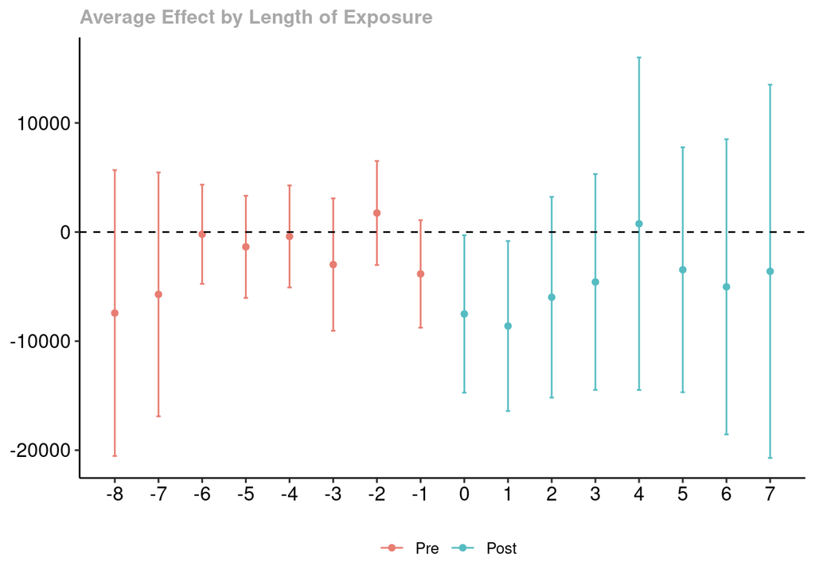

   ```r
   # part c
   ant_es <- aggte(ant_res, type="dynamic")
   ggdid(ant_es)
   ```

   ```r
   # part d
   ant_overall <- aggte(ant_res, type="group")
   summary(ant_overall)
   ```

   ```
   ##
   ## Call:
   ## aggte(MP = ant_res, type = "group")
   ##
   ## Reference: Callaway, Brantly and Pedro H.C. Sant'Anna.  "Difference-in-Differences with Multiple Time Periods." Journal of Econometrics, Vol. 225, No. 2, pp. 200-230, 2021. <https://doi.org/10.1016/j.jeconom.2020.12.001>, <https://arxiv.org/abs/1803.09015>
   ##
   ##
   ## Overall summary of ATT's based on group/cohort aggregation:
   ##        ATT    Std. Error     [ 95%  Conf. Int.]
   ##  -7711.634      2278.191  -12176.81   -3246.462 *
   ##
   ##
   ## Group Effects:
   ##  Group    Estimate Std. Error [95% Simult.  Conf. Band]
   ##   1986  -5683.6710   5439.967     -18410.08    7042.737
   ##   1987   -440.4114   6652.751     -16004.04   15123.216
   ##   1988    508.9529   5801.827     -13064.00   14081.906
   ##   1990 -14507.7979   4431.845     -24875.78   -4139.819 *
   ##   1991  -1896.8692   8626.903     -22078.88   18285.143
   ##   1992 -18858.4339   4548.870     -29500.19   -8216.682 *
   ##   1993 -26937.2785   5306.685     -39351.88  -14522.674 *
   ## ---
   ## Signif. codes: `*' confidence band does not cover 0
   ##
   ## Control Group:  Never Treated,  Anticipation Periods:  1
   ## Estimation Method:  Doubly Robust
   ```

# Question 3

Now, let’s suppose that we think that parallel trends holds only after we condition on a person sex and race (in reality, you could think of including many other variables in the parallel trends assumption, but let’s just keep it simple). In my view, I think allowing for anticipation is desirable in this setting too, so let’s keep allowing for one year of anticipation.

1. Answer parts (a), (c), and (d) of Question 1 but including `sex` and `white` as covariates.

   ```r
   # part a
   covs_res <- att_gt(yname="income",
                     tname="year",
                     idname="id",
                     gname="group",
                     data=job_displacement_data,
                     anticipation=1,
                     xformla=~female + white)
   summary(covs_res)
   ```

   ```
   ##
   ## Call:
   ## att_gt(yname = "income", tname = "year", idname = "id", gname = "group",
   ##     xformla = ~female + white, data = job_displacement_data,
   ##     anticipation = 1)
   ##
   ## Reference: Callaway, Brantly and Pedro H.C. Sant'Anna.  "Difference-in-Differences with Multiple Time Periods." Journal of Econometrics, Vol. 225, No. 2, pp. 200-230, 2021. <https://doi.org/10.1016/j.jeconom.2020.12.001>, <https://arxiv.org/abs/1803.09015>
   ##
   ## Group-Time Average Treatment Effects:
   ##  Group Time    ATT(g,t) Std. Error [95% Simult.  Conf. Band]
   ##   1986 1985  -1724.0034   2485.962    -8078.4326   4630.4257
   ##   1986 1986  -4258.8672   3541.813   -13312.1858   4794.4514
   ##   1986 1987  -4861.6136   3813.832   -14610.2467   4887.0196
   ##   1986 1988  -4729.6121   6044.470   -20180.0333  10720.8092
   ##   1986 1990  -8685.9902   5736.596   -23349.4486   5977.4683
   ```

   [output cut: 57 more lines]

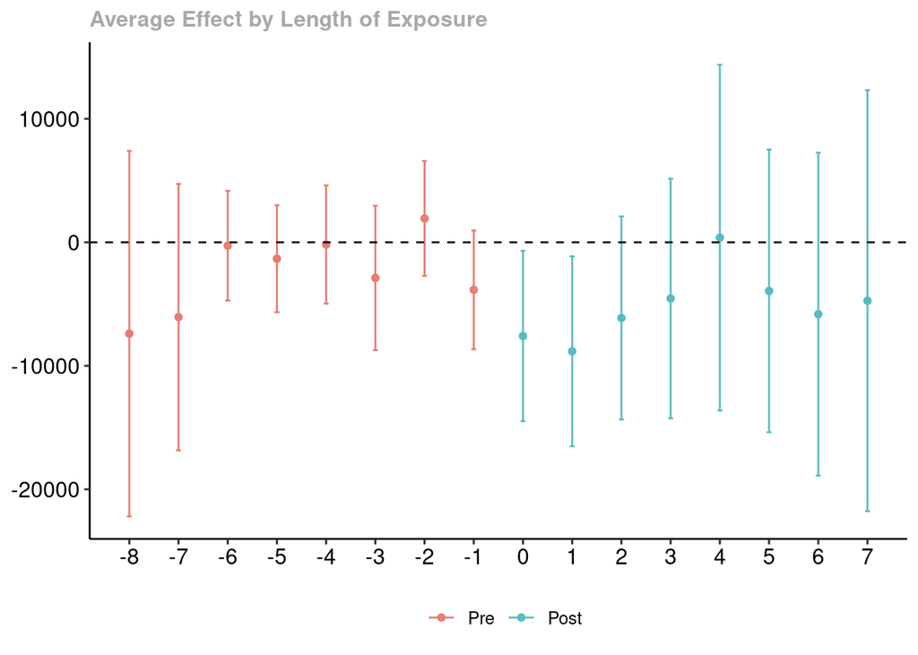

   ```r
   # part c
   covs_es <- aggte(covs_res, type="dynamic")
   ggdid(covs_es)
   ```

   ```r
   # part d
   covs_overall <- aggte(covs_res, type="group")
   summary(covs_overall)
   ```

   ```
   ##
   ## Call:
   ## aggte(MP = covs_res, type = "group")
   ##
   ## Reference: Callaway, Brantly and Pedro H.C. Sant'Anna.  "Difference-in-Differences with Multiple Time Periods." Journal of Econometrics, Vol. 225, No. 2, pp. 200-230, 2021. <https://doi.org/10.1016/j.jeconom.2020.12.001>, <https://arxiv.org/abs/1803.09015>
   ##
   ##
   ## Overall summary of ATT's based on group/cohort aggregation:
   ##        ATT    Std. Error     [ 95%  Conf. Int.]
   ##  -7931.965      2272.362  -12385.71   -3478.216 *
   ##
   ##
   ## Group Effects:
   ##  Group    Estimate Std. Error [95% Simult.  Conf. Band]
   ##   1986  -6506.8712   5198.329     -17805.40    4791.661
   ##   1987   -938.7858   6650.197     -15392.94   13515.370
   ##   1988    871.1134   6074.183     -12331.08   14073.307
   ##   1990 -14344.7830   4386.201     -23878.16   -4811.407 *
   ##   1991  -1798.2108   8226.271     -19677.95   16081.533
   ##   1992 -19369.1196   4434.008     -29006.40   -9731.835 *
   ##   1993 -27304.4090   5638.331     -39559.28  -15049.537 *
   ## ---
   ## Signif. codes: `*' confidence band does not cover 0
   ##
   ## Control Group:  Never Treated,  Anticipation Periods:  1
   ## Estimation Method:  Doubly Robust
   ```

2. By default, the `did` package uses the doubly robust approach that we discussed during our session. How do the results change if you use a regression approach or propensity score re-weighting?

   For simplicity, I am just going to show the overall results when using the regression approach and the propensity score re-weighting approach.

   ```r
   reg_res <- att_gt(yname="income",
                     tname="year",
                     idname="id",
                     gname="group",
                     data=job_displacement_data,
                     anticipation=1,
                     xformla=~female + white,
                     est_method="reg")
   summary(aggte(reg_res, type="group"))
   ```

   ```
   ##
   ## Call:
   ## aggte(MP = reg_res, type = "group")
   ##
   ## Reference: Callaway, Brantly and Pedro H.C. Sant'Anna.  "Difference-in-Differences with Multiple Time Periods." Journal of Econometrics, Vol. 225, No. 2, pp. 200-230, 2021. <https://doi.org/10.1016/j.jeconom.2020.12.001>, <https://arxiv.org/abs/1803.09015>
   ##
   ##
   ## Overall summary of ATT's based on group/cohort aggregation:
   ##        ATT    Std. Error     [ 95%  Conf. Int.]
   ##  -7919.691      2204.725  -12240.87    -3598.51 *
   ##
   ##
   ## Group Effects:
   ##  Group    Estimate Std. Error [95% Simult.  Conf. Band]
   ##   1986  -6434.0559   5447.339     -18557.12    5689.003
   ##   1987   -912.7508   7348.784     -17267.48   15441.978
   ##   1988    862.1890   5915.829     -12303.50   14027.873
   ##   1990 -14343.8838   4345.706     -24015.26   -4672.510 *
   ##   1991  -1796.2167   8508.337     -20731.53   17139.099
   ##   1992 -19441.0738   4480.758     -29413.01   -9469.142 *
   ##   1993 -27302.1029   5439.284     -39407.24  -15196.969 *
   ## ---
   ## Signif. codes: `*' confidence band does not cover 0
   ##
   ## Control Group:  Never Treated,  Anticipation Periods:  1
   ## Estimation Method:  Outcome Regression
   ```

   ```r
   ipw_res <- att_gt(yname="income",
                     tname="year",
                     idname="id",
                     gname="group",
                     data=job_displacement_data,
                     anticipation=1,
                     xformla=~female + white,
                     est_method="ipw")
   summary(aggte(ipw_res, type="group"))
   ```

   ```
   ##
   ## Call:
   ## aggte(MP = ipw_res, type = "group")
   ##
   ## Reference: Callaway, Brantly and Pedro H.C. Sant'Anna.  "Difference-in-Differences with Multiple Time Periods." Journal of Econometrics, Vol. 225, No. 2, pp. 200-230, 2021. <https://doi.org/10.1016/j.jeconom.2020.12.001>, <https://arxiv.org/abs/1803.09015>
   ##
   ##
   ## Overall summary of ATT's based on group/cohort aggregation:
   ##       ATT    Std. Error     [ 95%  Conf. Int.]
   ##  -7931.69      2390.903  -12617.77   -3245.607 *
   ##
   ##
   ## Group Effects:
   ##  Group    Estimate Std. Error [95% Simult.  Conf. Band]
   ##   1986  -6506.2796   5262.369     -17998.23    4985.671
   ##   1987   -938.6980   6737.173     -15651.32   13773.926
   ##   1988    871.1522   6220.903     -12714.04   14456.348
   ##   1990 -14345.0498   4284.361     -23701.23   -4988.870 *
   ##   1991  -1798.1771   8293.166     -19908.78   16312.422
   ##   1992 -19368.1395   4391.687     -28958.70   -9777.582 *
   ##   1993 -27303.3746   5493.634     -39300.36  -15306.389 *
   ## ---
   ## Signif. codes: `*' confidence band does not cover 0
   ##
   ## Control Group:  Never Treated,  Anticipation Periods:  1
   ## Estimation Method:  Inverse Probability Weighting
   ```

   You can see that the results are very similar across estimation strategies in this example.

# Question 4

Finally, the data that we have contains a variable called `occ_score` which is roughly a variable that measures the occupation “quality”. Suppose that we (i) are interested in including a person’s occupation in the parallel trends assumption, (ii) are satisfied that `occ_score` sufficiently summarizes a person’s occupation, but (iii) are worried that a person’s occupation is a “bad control” (in the sense that it could be affected by the treatment).

1. Repeat parts (a), (c), and (d) of Question 1 but including `occ_score` in the parallel trends assumption. Continue to allow for 1 year of anticipation effects.

```r
  # part a
  occ_res <- att_gt(yname="income",
                    tname="year",
                    idname="id",
                    gname="group",
                    data=job_displacement_data,
                    anticipation=1,
                    xformla=~female + white + occ_score)
  summary(occ_res)
```

```
##
## Call:
## att_gt(yname = "income", tname = "year", idname = "id", gname = "group",
##     xformla = ~female + white + occ_score, data = job_displacement_data,
##     anticipation = 1)
##
## Reference: Callaway, Brantly and Pedro H.C. Sant'Anna.  "Difference-in-Differences with Multiple Time Periods." Journal of Econometrics, Vol. 225, No. 2, pp. 200-230, 2021. <https://doi.org/10.1016/j.jeconom.2020.12.001>, <https://arxiv.org/abs/1803.09015>
##
## Group-Time Average Treatment Effects:
##  Group Time    ATT(g,t) Std. Error [95% Simult.  Conf. Band]
##   1986 1985  -2195.2252   2625.309     -8746.177   4355.7265
##   1986 1986  -4943.5726   3471.361    -13605.681   3718.5358
##   1986 1987  -5648.5248   4165.514    -16042.758   4745.7084
##   1986 1988  -5486.8776   6540.698    -21807.923  10834.1677
##   1986 1990  -9355.8673   5863.091    -23986.077   5274.3421
```

[output cut: 57 more lines]

```r
  # part c
  occ_es <- aggte(occ_res, type="dynamic")
  ggdid(occ_es)
```

[figure not shown]

```r
  # part d
  occ_overall <- aggte(occ_res, type="group")
  summary(occ_overall)
```

```
##
## Call:
## aggte(MP = occ_res, type = "group")
##
## Reference: Callaway, Brantly and Pedro H.C. Sant'Anna.  "Difference-in-Differences with Multiple Time Periods." Journal of Econometrics, Vol. 225, No. 2, pp. 200-230, 2021. <https://doi.org/10.1016/j.jeconom.2020.12.001>, <https://arxiv.org/abs/1803.09015>
##
##
## Overall summary of ATT's based on group/cohort aggregation:
##        ATT    Std. Error     [ 95%  Conf. Int.]
##  -7873.709      2304.661  -12390.76   -3356.657 *
##
##
## Group Effects:
##  Group    Estimate Std. Error [95% Simult.  Conf. Band]
##   1986  -7202.2226   5443.906     -18844.19    4439.746
##   1987   -718.3913   6546.163     -14717.57   13280.788
##   1988   1278.5603   6469.327     -12556.30   15113.425
##   1990 -14103.4696   4334.917     -23373.83   -4833.110 *
##   1991  -1181.1987   8361.300     -19062.11   16699.712
##   1992 -19746.4715   4728.862     -29859.29   -9633.648 *
##   1993 -27091.4909   6124.982     -40189.96  -13993.020 *
## ---
## Signif. codes: `*' confidence band does not cover 0
##
## Control Group:  Never Treated,  Anticipation Periods:  1
## Estimation Method:  Doubly Robust
```

2. What additional assumptions (with respect to occupation) do you need to make in order to rationalize this approach?